# Identify_Customer_Segments

### Prerequsite - Upgrade Scikit Learn

```python
import sklearn
print('The scikit-learn version is {}.'.format(sklearn.__version__))
```

```
The scikit-learn version is 0.24.2.
```

```python
import os
os.environ['PATH'] = f"{os.environ['PATH']}:/root/.local/bin"
```

```python
!python -m pip install --upgrade scikit-learn
import sklearn
print('The scikit-learn version is {}.'.format(sklearn.__version__))
```

```
The scikit-learn version is 0.24.2.
```

Restart the Kernel.

```python
# Now you can import and use OneHotEncoder
from sklearn.preprocessing import OneHotEncoder

encoder = OneHotEncoder(handle_unknown='ignore', sparse=False)
```

# Project: Identify Customer Segments

```python
# import libraries here; add more as necessary
import numpy as np
import pandas as pd
import matplotlib.pyplot as plt
import seaborn as sns

# magic word for producing visualizations in notebook
%matplotlib inline

'''
Import note: The classroom currently uses sklearn version 0.19.
If you need to use an imputer, it is available in sklearn.preprocessing.Imputer,
instead of sklearn.impute as in newer versions of sklearn.
'''
pd.options.display.max_rows = None
pd.options.display.max_columns = None
```

### Step 0: Load the Data

```python
# Load in the general demographics data.
azdias = pd.read_csv("Udacity_AZDIAS_Subset.csv", sep=';')

# Load in the feature summary file.
feature_summary = pd.read_csv("AZDIAS_Feature_Summary.csv", sep=';')
```

```python
# Check the structure of the data after it's loaded (e.g. print the number of
# rows and columns, print the first few rows).
print(f"AZDIAS Shape: {azdias.shape}")
print(f"Feature Summary Shape: {feature_summary.shape}\n")

# Review sample of AZDIAS and features tables as well as a sampling of the
# data types
print("\nAZDIAS Sample:")
display(azdias.head())

print("\nAZDIAS Feature Summary Sample:")
display(feature_summary.head())

print("\nAZDIAS Dtypes Sample:")
print(azdias.dtypes.head())
```

```
AZDIAS Shape: (891221, 85)
Feature Summary Shape: (85, 4)


AZDIAS Sample:
```

|  | AGER_TYP | ALTERSKATEGORIE_GROB | ANREDE_KZ | CJT_GESAMTTYP | FINANZ_MINIMALIST | FINANZ_SPARER | FINANZ_VORSORGER | FINANZ_ANLEGER | FINANZ_UNAUFFAELLIGER | FINANZ_HAUSBAUER | FINANZTYP | GEBURTSJAHR | GFK_URLAUBERTYP | GREEN_AVANTGARDE | HEALTH_TYP | LP_LEBENSPHASE_FEIN | LP_LEBENSPHASE_GROB | LP_FAMILIE_FEIN | LP_FAMILIE_GROB | LP_STATUS_FEIN | LP_STATUS_GROB | NATIONALITAET_KZ | PRAEGENDE_JUGENDJAHRE | RETOURTYP_BK_S | SEMIO_SOZ | SEMIO_FAM | SEMIO_REL | SEMIO_MAT | SEMIO_VERT | … |
| --- | --- | --- | --- | --- | --- | --- | --- | --- | --- | --- | --- | --- | --- | --- | --- | --- | --- | --- | --- | --- | --- | --- | --- | --- | --- | --- | --- | --- | --- | --- |
| 0 | -1 | 2 | 1 | 2.0 | 3 | 4 | 3 | 5 | 5 | 3 | 4 | 0 | 10.0 | 0 | -1 | 15.0 | 4.0 | 2.0 | 2.0 | 1.0 | 1.0 | 0 | 0 | 5.0 | 2 | 6 | 7 | 5 | 1 | … |
| 1 | -1 | 1 | 2 | 5.0 | 1 | 5 | 2 | 5 | 4 | 5 | 1 | 1996 | 10.0 | 0 | 3 | 21.0 | 6.0 | 5.0 | 3.0 | 2.0 | 1.0 | 1 | 14 | 1.0 | 5 | 4 | 4 | 3 | 1 | … |
| 2 | -1 | 3 | 2 | 3.0 | 1 | 4 | 1 | 2 | 3 | 5 | 1 | 1979 | 10.0 | 1 | 3 | 3.0 | 1.0 | 1.0 | 1.0 | 3.0 | 2.0 | 1 | 15 | 3.0 | 4 | 1 | 3 | 3 | 4 | … |
| 3 | 2 | 4 | 2 | 2.0 | 4 | 2 | 5 | 2 | 1 | 2 | 6 | 1957 | 1.0 | 0 | 2 | 0.0 | 0.0 | 0.0 | 0.0 | 9.0 | 4.0 | 1 | 8 | 2.0 | 5 | 1 | 2 | 1 | 4 | … |
| 4 | -1 | 3 | 1 | 5.0 | 4 | 3 | 4 | 1 | 3 | 2 | 5 | 1963 | 5.0 | 0 | 3 | 32.0 | 10.0 | 10.0 | 5.0 | 3.0 | 2.0 | 1 | 8 | 5.0 | 6 | 4 | 4 | 2 | 7 | … |

```
AZDIAS Feature Summary Sample:
```

|  | attribute | information_level | type | missing_or_unknown |
| --- | --- | --- | --- | --- |
| 0 | AGER_TYP | person | categorical | [-1,0] |
| 1 | ALTERSKATEGORIE_GROB | person | ordinal | [-1,0,9] |
| 2 | ANREDE_KZ | person | categorical | [-1,0] |
| 3 | CJT_GESAMTTYP | person | categorical | [0] |
| 4 | FINANZ_MINIMALIST | person | ordinal | [-1] |

```
AZDIAS Dtypes Sample:
AGER_TYP                  int64
ALTERSKATEGORIE_GROB      int64
ANREDE_KZ                 int64
CJT_GESAMTTYP           float64
FINANZ_MINIMALIST         int64
dtype: object
```

## Step 1: Preprocessing

### Step 1.1: Assess Missing Data

#### Step 1.1.1: Convert Missing Value Codes to NaNs

```python
# Identify missing or unknown data values and convert them to NaNs.
feature_name_col = 'attribute'
missing_col = 'missing_or_unknown'
```

```python
# Function to convert strings into lists
def missing_parser(encode_str):
    if pd.isna(encode_str) or str(encode_str).strip() in ("", "[]"):
        return []

    encode_str = str(encode_str).strip()

    if encode_str.startswith('[') and encode_str.endswith(']'):
        encode_str = encode_str[1:-1]

    new_items = []

    for item in encode_str.split(','):
        i = item.strip().strip("'").strip('"')
        if i == "":
            continue
        try:
            new_items.append(int(i))
        except ValueError:
            new_items.append(i)

    return new_items
```

```python
# Map for missing items
mapping = {
    row[feature_name_col]: missing_parser(row[missing_col])
    for _, row in feature_summary[[feature_name_col, missing_col]].iterrows()
}
```

```python
# Replace missing items with np.nan
for col, item in mapping.items():
    if col in azdias.columns and item:
        azdias[col].replace(to_replace=item, value=np.nan, inplace=True)
```

#### Step 1.1.2: Assess Missing Data in Each Column

```python
# Perform an assessment of how much missing data there is in each column of the
# dataset.
na_calc = azdias.isna().mean().sort_values(ascending=False)

print("Sample of columns by missing fraction:")
display(na_calc.head(10).to_frame("missing_mean"))
```

```
Sample of columns by missing fraction:
```

|  | missing_mean |
| --- | --- |
| TITEL_KZ | 0.997576 |
| AGER_TYP | 0.769554 |
| KK_KUNDENTYP | 0.655967 |
| KBA05_BAUMAX | 0.534687 |
| GEBURTSJAHR | 0.440203 |
| ALTER_HH | 0.348137 |
| REGIOTYP | 0.177357 |
| KKK | 0.177357 |
| W_KEIT_KIND_HH | 0.166051 |
| KBA05_ANTG4 | 0.149597 |

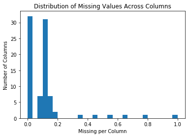

```python
# Histogram of missing across the columns
plt.figure()
plt.hist(na_calc.values, bins=30)
plt.xlabel("Missing per Column")
plt.ylabel("Number of Columns")
plt.title("Distribution of Missing Values Across Columns")
plt.show()
```

```python
# Investigate patterns in the amount of missing data in each column.
# Create missing table and get correlation info
missing1 = azdias.isna().astype(int)
missing_correlation = missing1.corr()
```

```python
# Find related pais of columns based on their missing item correlations with a
# floor of .7
missing_pair = []
cols = missing_correlation.columns.tolist()

for p in range(len(cols)):
    for o in range(p + 1, len(cols)):
        m = missing_correlation.iloc[p, o]
        if m >= .7:
            missing_pair.append((cols[p], cols[o], m))
```

```python
sorted_pairs = sorted(missing_pair, key=lambda x: x[2], reverse=True)
print("Top 10 correlated missing pairs:")

for a, b, c in sorted_pairs[:10]:
    print(f"{a} ~ {b} ; correlation = {c:.2f}")
```

```
Top 10 correlated missing pairs:
CJT_GESAMTTYP ~ GFK_URLAUBERTYP ; correlation = 1.00
CJT_GESAMTTYP ~ LP_STATUS_FEIN ; correlation = 1.00
CJT_GESAMTTYP ~ LP_STATUS_GROB ; correlation = 1.00
CJT_GESAMTTYP ~ RETOURTYP_BK_S ; correlation = 1.00
CJT_GESAMTTYP ~ ONLINE_AFFINITAET ; correlation = 1.00
GFK_URLAUBERTYP ~ LP_STATUS_FEIN ; correlation = 1.00
GFK_URLAUBERTYP ~ LP_STATUS_GROB ; correlation = 1.00
GFK_URLAUBERTYP ~ RETOURTYP_BK_S ; correlation = 1.00
GFK_URLAUBERTYP ~ ONLINE_AFFINITAET ; correlation = 1.00
HEALTH_TYP ~ SHOPPER_TYP ; correlation = 1.00
```

```python
# Remove the outlier columns from the dataset. (You'll perform other data
# engineering tasks such as re-encoding and imputation later.)

# Flag outliers based on their missing value
q1, q3 = na_calc.quantile(.25), na_calc.quantile(.75)
iqr = q3 - q1
cutoff = q3 + 1.5 * iqr

outlier_columns = na_calc[na_calc > cutoff].index.tolist()

print(f"Outlier cutoff: {cutoff:.2f}")
print(f"Number of dropped outlier columns: {len(outlier_columns)}")
print(f"Outlier column name: {outlier_columns[:6]}")

# Save a copy of the dropped columns for any needed use
cols_dropped = outlier_columns[:]

azdias.drop(columns=outlier_columns, inplace=True, errors="ignore")

print(f"AZDIAS shape after dropping columns: {azdias.shape}")
```

```
Outlier cutoff: 0.33
Number of dropped outlier columns: 6
Outlier column name: ['TITEL_KZ', 'AGER_TYP', 'KK_KUNDENTYP', 'KBA05_BAUMAX', 'GEBURTSJAHR', 'ALTER_HH']
AZDIAS shape after dropping columns: (891221, 79)
```

```python
# Retrieve statistics to discuss the findings thus far
median_missing = na_calc.median()
q3_missing = na_calc.quantile(.75)
max_missing = na_calc.max()

print(f"Median missing: {median_missing}")
print(f"Q3 missing: {q3_missing}")
print(f"Max missing: {max_missing}")
```

```
Median missing: 0.10451728583594866
Q3 missing: 0.13073637178657146
Max missing: 0.9975763587258379
```

#### Discussion 1.1.2: Assess Missing Data in Each Column

After converting 'unknown' items to "NaN", I computed the mean for the missing value of each feature. The distribution of missing items is right-skewed wth most columns having low missingness and only a small set of high missingness outliers.

Analysis of missingness: 1) Total features: 85 reviewed with 79 left after dropping columns 2) Median missing fraction across the columns: 0.10451728583594866 3) Q3 percentile: 0.13073637178657146 4) Max missing mean: 0.9975763587258379

The highest-missing columns were: TITEL_KZ, AGER_TYP, KK_KUNDENTYP, KBA05_BAUMAX, GEBURTSJAHR, ALTER_HH

Summary: Columns with high levels of missingness would add noise and cause issues with imputation for unsupervised discoveries. They were removed to increase interpretability of the numbers throughout the features. Features that have low levels of missingness will be imputed or re-encoded as necessary.

#### Step 1.1.3: Assess Missing Data in Each Row

```python
# How much data is missing in each row of the dataset?
row_missing_data = azdias.isna().mean(axis=1)

# Verify result and specific details
print(row_missing_data.describe())

row_missing_data.sort_values(ascending=False).head()
```

```
count    891221.000000
mean          0.071518
std           0.167528
min           0.000000
25%           0.000000
50%           0.000000
75%           0.037975
max           0.620253
dtype: float64
```

```
643174    0.620253
732775    0.620253
472919    0.607595
183108    0.594937
139316    0.594937
dtype: float64
```

```python
# Write code to divide the data into two subsets based on the number of missing
# values in each row.
# Setting a cutoff (eg 30%) of a missing row as a high missingness
cutoff = .3

low_index = row_missing_data <= cutoff
high_index = row_missing_data > cutoff

azdias_low = azdias.loc[low_index].copy()
azdias_high = azdias.loc[high_index].copy()

print("Cutoff: row_missing_data <= 0.30 is LOW, > 0.30 is HIGH")
print(f"Rows with low missing: {azdias_low.shape[0]}")
print(f"Rows with high missing: {azdias_high.shape[0]}")
```

```
Cutoff: row_missing_data <= 0.30 is LOW, > 0.30 is HIGH
Rows with low missing: 797837
Rows with high missing: 93384
```

```python
# Compare the distribution of values for at least five columns where there are
# no or few missing values, between the two subsets.
low_cols = na_calc[na_calc <= .05].index.tolist()
compare_cols = low_cols[:5]
print(f"Comparing these columns: {compare_cols}")
```

```
Comparing these columns: ['HH_EINKOMMEN_SCORE', 'CJT_GESAMTTYP', 'RETOURTYP_BK_S', 'ONLINE_AFFINITAET', 'LP_STATUS_FEIN']
```

```python
# Function to determine if there are unique integer values and turns them categorical in nature
def is_discrete(n, max_unique=20):
    if not pd.api.types.is_numeric_dtype(n):
        return False

    values = n.dropna()

    if values.empty:
        return False

    integers = np.all(np.isclose(values, np.round(values)))
    return integers and values.nunique(dropna=True) <= max_unique
```

```python
# Function to compare distributions with all proper categorical data or histogram if data is all numerical
def compare_distros(col, low, high, top_k=12):
    x_low = low[col].dropna()
    x_high = high[col].dropna()

    fig, axes = plt.subplots(1, 2, figsize=(12, 4))
    fig.suptitle(f"{col}, Low vs High Missing")

    if is_discrete(x_low) or (not pd.api.types.is_numeric_dtype(x_low)):
        low_n = x_low.value_counts(normalize=True).head(top_k)
        high_n = x_high.value_counts(normalize=True).reindex(low_n.index).fillna(0.0)

        sns.barplot(x=low_n.index, y=low_n.values, ax=axes[0])
        axes[0].set_title("Low Missing"); axes[0].set_xlabel(col); axes[0].set_ylabel("Proportion"); axes[0].tick_params(axis='x', rotation=45)

        sns.barplot(x=low_n.index, y=high_n.values, ax=axes[1])
        axes[1].set_title("High Missing"); axes[1].set_xlabel(col); axes[1].set_ylabel("Proportion"); axes[1].tick_params(axis='x', rotation=45)
    else:
        bins = np.histogram_bin_edges(pd.concat([x_low, x_high]), bins="auto")
        axes[0].hist(x_low, bins=bins, density=True); axes[0].set_title("Low Missing")
        axes[1].hist(x_high, bins=bins, density=True); axes[1].set_title("High Missing")
        for ax in axes:
            ax.set_xlabel(col); ax.set_ylabel("Density")

    plt.show()
```

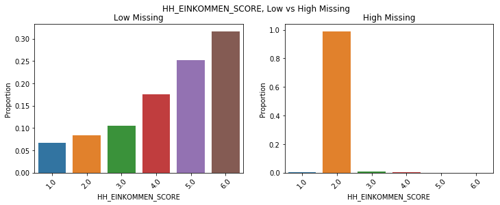

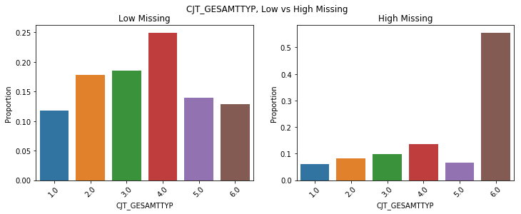

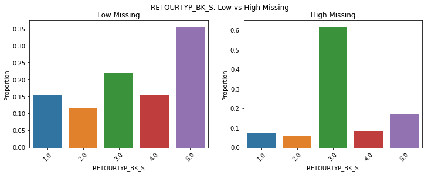

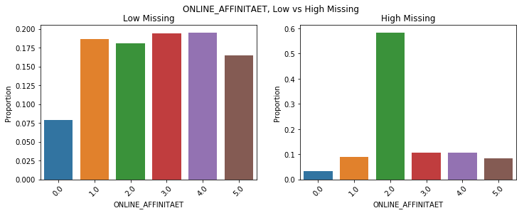

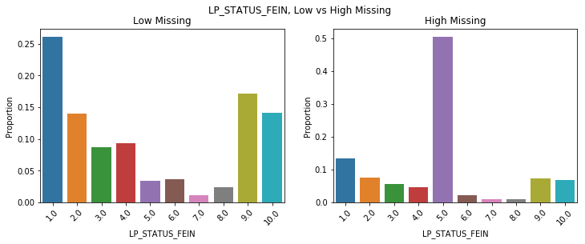

```python
# Run functions to check distribution graphs

for c in compare_cols:
    compare_distros(c, azdias_low, azdias_high)
```

#### Discussion 1.1.3: Assess Missing Data in Each Row

I computed the missing fractions for each row and split them at 30% (with less than 30%, or .3, being a "low missing" value and greater than that being "high missing").

I also compared the five lowest-missing columns (i.e., HH_EINKOMMEN_SCORE, CJT_GESAMTTYP, RETOURTYP_BK_S, ONLINE_AFFINITAET, LP_STATUS_FEIN) between the two subsets and used bar charts for side-by-side views of category proportions. In each case, 'high missing' subsets were concentrated on a single code (e.g. HH_EINKOMMEN_SCORE around 2 and LP_STATUS_FEIN≈5 around 5). The 'low missing', however, was more dispersed on the categories.

### Step 1.2: Select and Re-Encode Features

```python
# How many features are there of each data type?
display(feature_summary["type"].value_counts().sort_index())
```

```
categorical    21
interval        1
mixed           7
numeric         7
ordinal        49
Name: type, dtype: int64
```

```python
# Create copy of feature_summary for editing and recognizable column name
fs = feature_summary.copy()

fs["type"] = fs["type"].astype(str).str.strip().str.lower()

# keep only features that are actually in the lastest azdias
fs = fs[fs["attribute"].isin(azdias.columns)].copy()

# # Normalize feature names to reduce potential errors or mismatching
cat_type = {t: fs.loc[fs["type"] == t, "attribute"].tolist()
           for t in fs["type"].unique()}

categorical  = [col for col in cat_type.get("categorical", []) if col in azdias.columns]
ordinal      = [col for col in cat_type.get("ordinal", []) if col in azdias.columns]
numeric_int  = [col for col in (cat_type.get("numeric", []) + cat_type.get("interval", [])) if col in azdias.columns]
mixed        = [col for col in cat_type.get("mixed", []) if col in azdias.columns]

print(f"Categorical = {len(categorical)}\nOrdinal = {len(ordinal)}\n"
      f"Numeric/interval = {len(numeric_int)}\nMixed = {len(mixed)}")
```

```
Categorical = 18
Ordinal = 49
Numeric/interval = 6
Mixed = 6
```

```python
# Determine mixed columns info
mixed = [c for c in fs.loc[fs["type"] == "mixed", "attribute"] if c in azdias.columns]
print("Mixed-type candidates:", mixed)
```

```
Mixed-type candidates: ['LP_LEBENSPHASE_FEIN', 'LP_LEBENSPHASE_GROB', 'PRAEGENDE_JUGENDJAHRE', 'WOHNLAGE', 'CAMEO_INTL_2015', 'PLZ8_BAUMAX']
```

```python
# Assess categorical variables: which are binary, which are multi-level, and
# which one needs to be re-encoded?
cat_variables = {col: azdias[col].nunique(dropna=True) for col in categorical}
cat_variables = pd.Series(cat_variables).sort_values()
display(cat_variables)
```

```
ANREDE_KZ            2
OST_WEST_KZ          2
VERS_TYP             2
SOHO_KZ              2
GREEN_AVANTGARDE     2
NATIONALITAET_KZ     3
SHOPPER_TYP          4
LP_STATUS_GROB       5
LP_FAMILIE_GROB      5
FINANZTYP            6
ZABEOTYP             6
CJT_GESAMTTYP        6
GEBAEUDETYP          7
CAMEO_DEUG_2015      9
LP_STATUS_FEIN      10
LP_FAMILIE_FEIN     11
GFK_URLAUBERTYP     12
CAMEO_DEU_2015      44
dtype: int64
```

```python
# Determine binary vs multi categories

binary_categories = [c for c, n in cat_variables.items() if n == 2]
multi_categories = [c for c, n in cat_variables.items() if n > 2]

print(f"Binary categorical features: {binary_categories}")
print(f"Binary multi categorical features: {multi_categories}")
```

```
Binary categorical features: ['ANREDE_KZ', 'OST_WEST_KZ', 'VERS_TYP', 'SOHO_KZ', 'GREEN_AVANTGARDE']
Binary multi categorical features: ['NATIONALITAET_KZ', 'SHOPPER_TYP', 'LP_STATUS_GROB', 'LP_FAMILIE_GROB', 'FINANZTYP', 'ZABEOTYP', 'CJT_GESAMTTYP', 'GEBAEUDETYP', 'CAMEO_DEUG_2015', 'LP_STATUS_FEIN', 'LP_FAMILIE_FEIN', 'GFK_URLAUBERTYP', 'CAMEO_DEU_2015']
```

```python
# Determine if binary categories are numeric for re-encoding needs
for n in binary_categories:
    print(f"\n{n}")
    print(azdias[n].dropna().unique())
```

```
ANREDE_KZ
[1 2]

OST_WEST_KZ
['W' 'O']

VERS_TYP
[2. 1.]

SOHO_KZ
[1. 0.]

GREEN_AVANTGARDE
[0 1]
```

#### Step 1.2.1: Re-Encode Categorical Features

```python
# Re-encode categorical variable to be kept in the analysis
string = azdias['OST_WEST_KZ']

mask = string.notna()
normal = string.copy()
normal.loc[mask] = string.loc[mask].astype(str).str.strip().str.upper()

mapped = normal.map({"O": 0.0, "W": 1.0})
azdias['OST_WEST_KZ'] = mapped.astype("float32", copy=False)

print("Unique (non-null):", sorted(azdias["OST_WEST_KZ"].dropna().unique()))
print("NaN %:", azdias["OST_WEST_KZ"].isna().mean())
print(azdias["OST_WEST_KZ"].value_counts(dropna=False).head())
```

```
Unique (non-null): [0.0, 1.0]
NaN %: 0.10451728583594866
 1.0    629528
 0.0    168545
NaN      93148
Name: OST_WEST_KZ, dtype: int64
```

```python
# Function to map the remaining binaries to {0, 1} for consistency
def update_map(df, col):
    if col not in df.columns:
        return

    c = df[col]
    v = sorted(pd.unique(c.dropna()))

    if set(v) == {0.0, 1.0} or set(v) == {0, 1}:
        df[col] = c.astype("float32", copy=False)
        return

    if len(v) != 2:
        return

    v0, v1 = v
    mapping = {v0: 0.0, v1: 1.0}

    df[col] = c.map(mapping).astype('float32')

for col in ["ANREDE_KZ","VERS_TYP","SOHO_KZ","GREEN_AVANTGARDE"]:
    update_map(azdias, col)

for n in binary_categories:
    print(f"\n{n}")
    print(azdias[n].dropna().unique())
```

```
ANREDE_KZ
[0. 1.]

OST_WEST_KZ
[1. 0.]

VERS_TYP
[1. 0.]

SOHO_KZ
[1. 0.]

GREEN_AVANTGARDE
[0. 1.]
```

#### Discussion 1.2.1: Re-Encode Categorical Features

The categorical variables were reviewed and split by cardinality. Five of the variables were binary (ANREDE_KZ, OST_WEST_KZ, VERS_TYP, SOHO_KZ, GREEN_AVANTGARDE) and were put into a standard 0.0/1.0 'float' format using a mapping function.

Multi-level categories, to be reviewed in the following steps, were excluded and ensure the features at this point are completely numeric. The working set now has numeric/interval features, ordinal features, and re-encoded binary categoricals.

#### Step 1.2.2: Engineer Mixed-Type Features

```python
# Investigate "PRAEGENDE_JUGENDJAHRE"
print(azdias["PRAEGENDE_JUGENDJAHRE"].dtype)
print("Non-null count:", azdias["PRAEGENDE_JUGENDJAHRE"].notna().sum())
```

```
float64
Non-null count: 783057
```

```python
print(azdias["PRAEGENDE_JUGENDJAHRE"].value_counts(dropna=False).sort_index())
```

```
 1.0      21282
 2.0       7479
 3.0      55195
 4.0      20451
 5.0      86416
 6.0      25652
 7.0       4010
 8.0     145988
 9.0      33570
 10.0     85808
 11.0     35752
 12.0     24446
 13.0      5764
 14.0    188697
 15.0     42547
NaN      108164
Name: PRAEGENDE_JUGENDJAHRE, dtype: int64
```

```python
print(azdias["PRAEGENDE_JUGENDJAHRE"].describe())
```

```
count    783057.000000
mean          9.280709
std           4.032107
min           1.000000
25%           6.000000
50%           9.000000
75%          14.000000
max          15.000000
Name: PRAEGENDE_JUGENDJAHRE, dtype: float64
```

```python
# Engineer two new variables for PRAEGENDE_JUGENDJAHRE
if "PRAEGENDE_JUGENDJAHRE" in azdias.columns:
    pj = pd.to_numeric(azdias["PRAEGENDE_JUGENDJAHRE"], errors='coerce')
    mask = pj.notna()
    pj_int = pj[mask].astype(np.int64)

    avantgarde = {2, 4, 6, 7, 9, 11, 13, 15}
    movement = np.full(pj.shape, np.nan, dtype="float32")
    movement[mask] = np.isin(pj_int.values, list(avantgarde)).astype("float32")
    azdias["PJ_MOVEMENT"] = movement

    pj_decade = {
        1: 1940, 2: 1940,
        3: 1950, 4: 1950,
        5: 1960, 6: 1960, 7: 1960,
        8: 1970, 9: 1970,
        10: 1980, 11: 1980, 12: 1980, 13: 1980,
        14: 1990, 15: 1990
    }

    decade = np.full(pj.shape, np.nan, dtype="float32")
    decade_mapped = pd.Series(pj_int).map(pj_decade).astype("float32").values
    decade[mask] = decade_mapped
    azdias["PJ_DECADE"] = decade
```

```python
# Verify updated info
for n in ["PJ_MOVEMENT","PJ_DECADE"]:
    if n in azdias.columns:
        print(f"{n}: dtype={azdias[n].dtype}, uniques(non-null)={sorted(pd.unique(azdias[n].dropna()))[:5]}")
```

```
PJ_MOVEMENT: dtype=float32, uniques(non-null)=[0.0, 1.0]
PJ_DECADE: dtype=float32, uniques(non-null)=[1940.0, 1950.0, 1960.0, 1970.0, 1980.0]
```

```python
# Investigate "CAMEO_INTL_2015" and engineer two new variables.
print(azdias["CAMEO_INTL_2015"].dtype)
print("Non-null count:", azdias["CAMEO_INTL_2015"].notna().sum())
```

```
object
Non-null count: 791869
```

```python
print(azdias["CAMEO_INTL_2015"].value_counts(dropna=False).sort_index())
```

```
12      13249
13      26336
14      62884
15      16974
22      33155
23      26750
24      91158
25      39628
31      19024
32      10354
33       9935
34      18524
35      10356
41      92336
43      56672
44      14820
45      26132
51     133694
52      20542
54      45391
55      23955
NaN     99352
Name: CAMEO_INTL_2015, dtype: int64
```

```python
print(azdias["CAMEO_INTL_2015"].describe())
```

```
count     791869
unique        21
top           51
freq      133694
Name: CAMEO_INTL_2015, dtype: object
```

```python
# Engineer two new variables for CAMEO_INTL_2015
if "CAMEO_INTL_2015" in azdias.columns:
    cam = azdias["CAMEO_INTL_2015"].astype(str).str.strip().str.upper()
    cam = cam.replace({"": np.nan, "X": np.nan, "XX": np.nan})
    azdias["CAMEO_WEALTH"] = pd.to_numeric(cam.str[0], errors="coerce").astype("float32")
    azdias["CAMEO_LIFESTAGE"] = pd.to_numeric(cam.str[1], errors="coerce").astype("float32")
```

```python
for a in ["CAMEO_WEALTH","CAMEO_LIFESTAGE"]:
    if a in azdias.columns:
        print(f"{a}: dtype={azdias[a].dtype}, uniques(non-null)={sorted(pd.unique(azdias[a].dropna()))[:5]}")
```

```
CAMEO_WEALTH: dtype=float32, uniques(non-null)=[1.0, 2.0, 3.0, 4.0, 5.0]
CAMEO_LIFESTAGE: dtype=float32, uniques(non-null)=[1.0, 2.0, 3.0, 4.0, 5.0]
```

#### Discussion 1.2.2: Engineer Mixed-Type Features

In accordance with the Data_Dictionary.md, there were multiple encode updates to the variables:

1) PRAEGENDE_JUGENDJAHRE had codes 1 through 15 which combined "decade" and "movement". Using the dictionary, PRAEGENDE_JUGENDJAHRE split into PJ_DECADE (1940 through 1990) and PJ_MOVEMENT (0 = mainstream and 1 = avantgarde).

2) CAMEO_INTL_2015 encoded wealth in tens digits and life stage in ones digits. It also had 'XX' as unknown. CAMEO_INTL_2015 was split into CAMEO_WEALTH (using 1 through 5) and CAMEO_LIFESTAGE (also 1 through 5).

3) WOHNLAGE and PLZ8_BAUMAX were kept as nuemeric and other mixed features were dropped, such as LP_LEBENSPHASE.

Mixed features are numeric and in line with the data dictionary definitions.

#### Step 1.2.3: Complete Feature Selection

```python
# If there are other re-engineering tasks you need to perform, make sure you
# take care of them here. (Dealing with missing data will come in step 2.1.)
binary_columns = [col for col in ["ANREDE_KZ","OST_WEST_KZ","VERS_TYP","SOHO_KZ","GREEN_AVANTGARDE"] if col in azdias.columns]

engineer = [col for col in ["PJ_DECADE","PJ_MOVEMENT","CAMEO_WEALTH","CAMEO_LIFESTAGE"] if col in azdias.columns]
mix = [col for col in ["WOHNLAGE","PLZ8_BAUMAX"] if col in azdias.columns]

# Drop previous composite/multi features
dropped = ["PRAEGENDE_JUGENDJAHRE","CAMEO_INTL_2015", "LP_LEBENSPHASE_FEIN","LP_LEBENSPHASE_GROB"]

azdias = azdias.drop(columns=[col for col in dropped if col in azdias.columns], errors="ignore")

# Drop multi-level categoricals identified in earlier steps
multi_dropped = [
    "CJT_GESAMTTYP","FINANZTYP","ZABEOTYP","GEBAEUDETYP",
    "CAMEO_DEUG_2015","CAMEO_DEU_2015","GFK_URLAUBERTYP",
    "SHOPPER_TYP","LP_STATUS_FEIN","LP_STATUS_GROB",
    "LP_FAMILIE_FEIN","LP_FAMILIE_GROB","NATIONALITAET_KZ"
]
azdias = azdias.drop(columns=[col for col in multi_dropped if col in azdias.columns], errors="ignore")

# Final list of columns
keeping = list(
    set(numeric_int) |
    set(ordinal) |
    set(binary_columns) |
    set(engineer) |
    set(mix)
)

# Only use low missing rows as previously defined (i.e. <= 30 percent)
if 'azdias_low' in globals():
    df_working = azdias.loc[azdias_low.index, keeping].copy()
else:
    row_missing = azdias.isna().mean(axis=1)
    df_working = azdias.loc[row_missing <= .30, keeping].copy()
```

```python
# Check for final items in the working dataframe for verification
check = [col for col in df_working.columns if not pd.api.types.is_numeric_dtype(df_working[col])]

print(f"Non-numeric columns: {check}")
print(f"Shape: {df_working.shape}")

azdias_working = df_working
```

```
Non-numeric columns: []
Shape: (797837, 66)
```

### Step 1.3: Create a Cleaning Function

```python
import ast

def build_missing_map(feature_summary):
    fs = feature_summary.copy()
    fs = fs["missing_or_unknown"].astype(str).str.strip() != ""
    fs = feature_summary.loc[fs]
    missing = {}
    for _, r in fs.iterrows():
        col = r["attribute"]
        raw = str(r["missing_or_unknown"]).strip()
        try:
            code = ast.literal_eval(raw)
            if not isinstance(code, (list, tuple)): code = [code]
        except Exception:
            token = [t.strip().strip("'").strip('"')
                     for t in raw.strip("[]").split(",") if t.strip()]
            code = []
            for t in token:
                try:
                    f = float(t); code.append(int(f) if f.is_integer() else f)
                except Exception:
                    code.append(t)
        missing[col] = code
    return missing

missing_map = build_missing_map(feature_summary)

def clean_data(df, feature_summary, missing_map):
    output = df.copy()

    mm = missing_map if missing_map is not None else build_missing_map(feature_summary)
    for col, code in mm.items():
        if col not in output.columns:
            continue

        # flatten codes
        flattened = []
        for c in (code if isinstance(code, (list, tuple, set)) else [code]):
            if isinstance(c, (list, tuple, np.ndarray, set)):
                flattened.extend(list(c))
            else:
                flattened.append(c)

        # split string vs numeric
        str_codes = {str(c).strip().upper() for c in flattened if isinstance(c, str)}
        num_codes = [c for c in flattened if not isinstance(c, str)]

        s = output[col]

        if str_codes:
            su = s.astype(str).str.strip().str.upper()
            s = s.mask(su.isin(str_codes), np.nan)

        if num_codes:
            sn = pd.to_numeric(s, errors="ignore")
            s = sn.mask(pd.Series(sn).isin(num_codes).values, np.nan)

        output[col] = s

    # Drops
    high_missing = ['TITEL_KZ','AGER_TYP','KK_KUNDENTYP','KBA05_BAUMAX','GEBURTSJAHR','ALTER_HH']
    output = output.drop(columns=[col for col in high_missing if col in output.columns], errors="ignore")

    multi_drop = ["CJT_GESAMTTYP","FINANZTYP","ZABEOTYP","GEBAEUDETYP",
                  "CAMEO_DEUG_2015","CAMEO_DEU_2015","GFK_URLAUBERTYP",
                  "SHOPPER_TYP","LP_STATUS_FEIN","LP_STATUS_GROB",
                  "LP_FAMILIE_FEIN","LP_FAMILIE_GROB","NATIONALITAET_KZ"]
    output = output.drop(columns=[col for col in multi_drop if col in output.columns], errors="ignore")

    # Binaries
    binary_feats = ["ANREDE_KZ","OST_WEST_KZ","VERS_TYP","SOHO_KZ","GREEN_AVANTGARDE"]
    if "OST_WEST_KZ" in output.columns:
        s = output["OST_WEST_KZ"]
        if not pd.api.types.is_numeric_dtype(s):
            m = s.notna()
            normal = s.astype(str).str.strip().str.upper()
            mapped = normal.map({"O": 0.0, "W": 1.0})
            rem = mapped.isna() & m
            if rem.any():
                coerced = pd.to_numeric(normal[rem], errors="coerce")
                mapped.loc[rem] = coerced.where(coerced.isin([0, 1]), other=np.nan)
            output["OST_WEST_KZ"] = mapped.astype("float32")
        else:
            output["OST_WEST_KZ"] = s.astype("float32", copy=False)

    for col in [col for col in binary_feats if col in output.columns and col != "OST_WEST_KZ"]:
        s = output[col]
        if not pd.api.types.is_numeric_dtype(s):
            s = s.astype(str).str.strip().str.upper().map({"O": 0.0, "W": 1.0})
        output[col] = pd.to_numeric(s, errors="coerce").astype("float32")

    # PJ_*
    if ("PRAEGENDE_JUGENDJAHRE" in output.columns) and (
        ("PJ_MOVEMENT" not in output.columns) or ("PJ_DECADE" not in output.columns)
    ):
        pj = pd.to_numeric(output["PRAEGENDE_JUGENDJAHRE"], errors="coerce")
        mask = pj.notna()
        pj_int = pj[mask].astype(np.int64)
        avantgarde = {2,4,6,7,9,11,13,15}
        movement = np.full(pj.shape, np.nan, dtype="float32")
        movement[mask] = np.isin(pj_int.values, list(avantgarde)).astype("float32")
        output["PJ_MOVEMENT"] = movement
        decades = {1:1940,2:1940,
                   3:1950,4:1950,
                   5:1960,6:1960,7:1960,
                   8:1970,9:1970,
                   10:1980,11:1980,12:1980,13:1980,
                   14:1990,15:1990}
        decade = np.full(pj.shape, np.nan, dtype="float32")
        decade[mask] = pd.Series(pj_int).map(decades).astype("float32").values
        output["PJ_DECADE"] = decade

    # CAMEO_*
    if ("CAMEO_INTL_2015" in output.columns) and (
        ("CAMEO_WEALTH" not in output.columns) or ("CAMEO_LIFESTAGE" not in output.columns)
    ):
        s = output["CAMEO_INTL_2015"].astype(str).str.strip().str.upper()
        s = s.replace({"": np.nan, "X": np.nan, "XX": np.nan})
        output["CAMEO_WEALTH"]    = pd.to_numeric(s.str[0], errors="coerce").astype("float32")
        output["CAMEO_LIFESTAGE"] = pd.to_numeric(s.str[1], errors="coerce").astype("float32")

    # Mixed ordinals
    for col in ["WOHNLAGE","PLZ8_BAUMAX"]:
        if col in output.columns:
            output[col] = pd.to_numeric(output[col], errors="coerce").astype("float32")

    # Keep set
    fs = feature_summary.copy()
    fs["type"] = fs["type"].astype(str).str.strip().str.lower()
    present     = set(output.columns)
    numeric_int = [col for col in fs.loc[fs["type"].isin(["numeric","interval"]), "attribute"] if col in present]
    ordinal     = [col for col in fs.loc[fs["type"] == "ordinal", "attribute"] if col in present]
    binaries    = [col for col in ["ANREDE_KZ","OST_WEST_KZ","VERS_TYP","SOHO_KZ","GREEN_AVANTGARDE"] if col in present]
    engineered  = [col for col in ["PJ_DECADE","PJ_MOVEMENT","CAMEO_WEALTH","CAMEO_LIFESTAGE"] if col in present]
    kept_mixed  = [col for col in ["WOHNLAGE","PLZ8_BAUMAX"] if col in present]
    keeping = set(numeric_int) | set(ordinal) | set(binaries) | set(engineered) | set(kept_mixed)
    output = output[[col for col in output.columns if col in keeping]].copy()

    # numeric enforce
    for col in output.columns:
        if not pd.api.types.is_numeric_dtype(output[col]):
            output[c] = pd.to_numeric(output[col], errors="coerce")

    return output
```

## Step 2: Feature Transformation

### Step 2.1: Apply Feature Scaling

```python
# If you've not yet cleaned the dataset of all NaN values, then investigate and
# do that now.

# Review dtypes to confirm numeric only
non_numeric = azdias_working.select_dtypes(exclude=[np.number]).columns.tolist()
print(f"Non-numeric columns: {non_numeric}")

# Review missingness for NaN info
na_individual = int(azdias_working.isna().sum().sum())
na_row = int(azdias_working.isna().any(axis=1).sum())
na_col = int(azdias_working.isna().any(axis=0).sum())

print(f"Number of NA Cells: {na_individual}")
print(f"Number of NA Rows: {na_row}")
print(f"Number of NA Columns: {na_col}")

# Save column order
feature_order = azdias_working.columns.tolist()
```

```
Non-numeric columns: []
Number of NA Cells: 782202
Number of NA Rows: 174626
Number of NA Columns: 36
```

```python
# Impute NA values to median to keep robust before scaling
from sklearn.impute import SimpleImputer

imputer = SimpleImputer(strategy='median')
X_impute = imputer.fit_transform(azdias_working)
X_imputed = pd.DataFrame(X_impute, index=azdias_working.index, columns=azdias_working.columns)

print(f"Imputed Shape: {X_imputed.shape}")
print(f"NA after imputing: {np.isnan(X_imputed.values).any()}")
```

```
Imputed Shape: (797837, 66)
NA after imputing: False
```

```python
# Apply feature scaling to the general population demographics data.
from sklearn.preprocessing import StandardScaler

scaler = StandardScaler(with_mean=True, with_std=True)
X_scaled = scaler.fit_transform(X_imputed)

print(f"Scale Shape: {X_scaled.shape}")
print(f"Average Summary: {np.mean(X_scaled, axis=0)[:10].round(4)}")
print(f"Standard Deviation Summary: {np.std(X_scaled, axis=0, ddof=0)[:10]}")
```

```
Scale Shape: (797837, 66)
Average Summary: [-0. -0.  0. -0.  0.  0.  0. -0. -0. -0.]
Standard Deviation Summary: [1. 1. 1. 1. 1. 1. 1. 1. 1. 1.]
```

### Discussion 2.1: Apply Feature Scaling

The dataset was cleaned of all NaN values through imputation and all demographic variables were scaled before apply PCA. I imputed the values use the median for each NaN value to ensure we have less sensitivity to some of the extreme values. This also keeps the centralized tendency of the skewed distributions with this demographic data. All NaN values were confirmed as removed while maintaining the shape.

After imputing the values, StandardScaler was using to standardize each value. The transform subtracted the mean from each value and divided by the standard deviation in order to get the z-score to represent each initial value. Every feature now has an average of approximately zero and a standard deviation of 1. The dataset, again, kept its shape and the values were confirmed with a summary check.

The imputer and scaler fits will be used on CUSTOMERS at a later step to ensure consistency between both datasets.

### Step 2.2: Perform Dimensionality Reduction

```python
# Apply PCA to the data.
from sklearn.decomposition import PCA

pca_complete = PCA(random_state=0)
pca_complete.fit(X_scaled)
```

```
PCA(random_state=0)
```

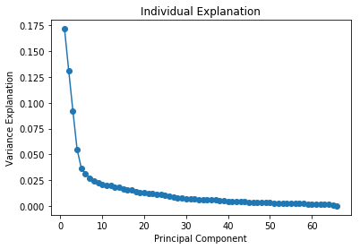

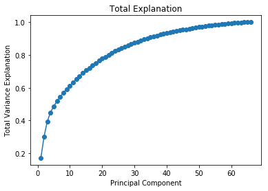

```python
# Investigate the variance accounted for by each principal component.
variance_explanation = pca_complete.explained_variance_ratio_
sum_explanation = np.cumsum(variance_explanation)

# Plot the variance for investigation
plt.figure()
plt.plot(np.arange(1, len(variance_explanation) + 1), variance_explanation, marker='o')
plt.xlabel("Principal Component")
plt.ylabel("Variance Explanation")
plt.title("Individual Explanation")
plt.show()

plt.figure()
plt.plot(np.arange(1, len(sum_explanation)+1), sum_explanation, marker='o')
plt.xlabel("Principal Component")
plt.ylabel("Total Variance Explanation")
plt.title("Total Explanation")
plt.show()
```

```python
# Re-apply PCA to the data while selecting for number of components to retain.
# Using 40 components to get at least 90% variance if possible
n_components = 40
pca = PCA(n_components=n_components, random_state=0)
X_pca = pca.fit_transform(X_scaled)

print(f"Refit Shape: {X_pca.shape}")
print(f"Total Variance Explanation: {np.sum(pca.explained_variance_ratio_).round(4)}")
```

```
Refit Shape: (797837, 40)
Total Variance Explanation: 0.9328
```

### Discussion 2.2: Perform Dimensionality Reduction

I applied PCA to the scaled features to reduce the dimensionality of the demographics dataset. PCA is used to find the linear combinations of the variable to capture the direction of the greatest variance. As seen in the plots, the first half of the components provide an explanation for a very large portion of the variance and, as we go above 40 to 50 components, they start to provide very little. Through plotting and investigating the final variance dataset, I used 40 components to achieve a high, but still manageable, component set that explains over 93% of variance.

I chose 40 to preserve a high amount of the content and context of the original dataset while still getting a reduced feature set. At 93%, we ensure the overall structure of the data is maintained and remove a good deal of noise and redundant features.

### Step 2.3: Interpret Principal Components

```python
# Defining a function to reuse to map weights to principal components, with a sample of the overall absolute weights and
# splitting positive and negative values for quicker interpretation
az_features = list(azdias_working.columns)

def pca_weight(pca_set, j, feature_name, topn=10):
    w = pca_set.components_[j]
    df = pd.DataFrame({
        "feature": feature_name,
        "weight": w,
    })
    df["abs_w"] = df["weight"].abs()
    df = df.sort_values("abs_w", ascending=False)

    print(f"PC{j + 1} top weight")
    print(df[['feature', 'weight']].head(topn).to_string(index=False))

    print("\nTop Positive")
    print(df.query("weight > 0")[['feature', 'weight']].head(topn).to_string(index=False))

    print("\nTop Negative")
    print(df.query("weight < 0")[['feature', 'weight']].head(topn).to_string(index=False))

    return df
```

```python
# Map weights for the first principal component to corresponding feature names and then print the linked values,
# sorted by weight.
df_pc1 = pca_weight(pca, 0, az_features, topn=10)
```

```
PC1 top weight
feature    weight
       MOBI_REGIO -0.240009
       PLZ8_ANTG3  0.229606
       PLZ8_ANTG1 -0.229396
       PLZ8_ANTG4  0.224039
      KBA05_ANTG1 -0.219497
      PLZ8_BAUMAX  0.219163
        KBA05_GBZ -0.214691
     CAMEO_WEALTH  0.203835
FINANZ_MINIMALIST -0.203319
      ORTSGR_KLS9  0.203125

Top Positive
feature    weight
        PLZ8_ANTG3  0.229606
        PLZ8_ANTG4  0.224039
       PLZ8_BAUMAX  0.219163
      CAMEO_WEALTH  0.203835
       ORTSGR_KLS9  0.203125
          EWDICHTE  0.200696
HH_EINKOMMEN_SCORE  0.196401
  FINANZ_HAUSBAUER  0.162967
       KBA05_ANTG4  0.155922
        PLZ8_ANTG2  0.155742

Top Negative
feature    weight
       MOBI_REGIO -0.240009
       PLZ8_ANTG1 -0.229396
      KBA05_ANTG1 -0.219497
        KBA05_GBZ -0.214691
FINANZ_MINIMALIST -0.203319
         PLZ8_GBZ -0.171341
      KONSUMNAEHE -0.170826
       INNENSTADT -0.168865
         BALLRAUM -0.130813
  CAMEO_LIFESTAGE -0.120878
```

```python
# Map weights for the second principal component to corresponding feature names
# and then print the linked values, sorted by weight.
df_pc2 = pca_weight(pca, 1, az_features, topn=10)
```

```
PC2 top weight
feature    weight
 ALTERSKATEGORIE_GROB  0.269892
            SEMIO_REL -0.262472
            PJ_DECADE -0.260138
        FINANZ_SPARER -0.248839
     FINANZ_VORSORGER  0.242617
          SEMIO_TRADV -0.238425
        SEMIO_PFLICHT -0.237402
            SEMIO_ERL  0.234537
FINANZ_UNAUFFAELLIGER -0.232781
           SEMIO_KULT -0.222906

Top Positive
feature    weight
ALTERSKATEGORIE_GROB  0.269892
    FINANZ_VORSORGER  0.242617
           SEMIO_ERL  0.234537
          SEMIO_LUST  0.189856
      RETOURTYP_BK_S  0.164792
      W_KEIT_KIND_HH  0.114974
          SEMIO_KRIT  0.111795
          SEMIO_KAEM  0.105336
    FINANZ_HAUSBAUER  0.098953
   FINANZ_MINIMALIST  0.089479

Top Negative
feature    weight
            SEMIO_REL -0.262472
            PJ_DECADE -0.260138
        FINANZ_SPARER -0.248839
          SEMIO_TRADV -0.238425
        SEMIO_PFLICHT -0.237402
FINANZ_UNAUFFAELLIGER -0.232781
           SEMIO_KULT -0.222906
       FINANZ_ANLEGER -0.211927
            SEMIO_FAM -0.188169
            SEMIO_RAT -0.179682
```

```python
# Map weights for the third principal component to corresponding feature names
# and then print the linked values, sorted by weight.
df_pc3 = pca_weight(pca, 2, az_features, topn=10)
```

```
PC3 top weight
feature    weight
     ANREDE_KZ -0.368981
    SEMIO_VERT  0.346528
    SEMIO_KAEM -0.338092
     SEMIO_DOM -0.313837
    SEMIO_KRIT -0.277144
     SEMIO_SOZ  0.262289
     SEMIO_FAM  0.249913
    SEMIO_KULT  0.235803
     SEMIO_RAT -0.216649
FINANZ_ANLEGER -0.188908

Top Positive
feature    weight
          SEMIO_VERT  0.346528
           SEMIO_SOZ  0.262289
           SEMIO_FAM  0.249913
          SEMIO_KULT  0.235803
   FINANZ_MINIMALIST  0.161150
      RETOURTYP_BK_S  0.106301
    FINANZ_VORSORGER  0.100043
      W_KEIT_KIND_HH  0.087300
ALTERSKATEGORIE_GROB  0.077849
           SEMIO_REL  0.070002

Top Negative
feature    weight
            ANREDE_KZ -0.368981
           SEMIO_KAEM -0.338092
            SEMIO_DOM -0.313837
           SEMIO_KRIT -0.277144
            SEMIO_RAT -0.216649
       FINANZ_ANLEGER -0.188908
            SEMIO_ERL -0.177443
        FINANZ_SPARER -0.106591
            PJ_DECADE -0.105058
FINANZ_UNAUFFAELLIGER -0.097608
```

### Discussion 2.3: Interpret Principal Components

I created a function to map the weights of a principal component to corresponding features in order to understand what each axis represents as well as the top positive/negative values. The larger positives mean that higher values in the feature will push higher scoress on the component. The larger negatives, on the other hand, pull the scores lower.

After observing the first three principal components, we find a few details to interpret from the positive/negative values:

1) Principal Component 1(Affluence / Urban Density): We have strong positives on the following features: PLZ8_ANTG3/4, PLZ8_BAUMAX, CAMEO_WEALTH, HH_EINKOMMEN_SCORE, EWDICHTE, ORTSGR_KLS9.

And strong negatives on these features: MOBI_REGIO, PLZ8_ANTG1, KBA05_ANTG1, KBA05_GBZ, FINANZ_MINIMALIST, KONSUMNAEHE, INNENSTADT.

This helps us interpret that Principal Component 1 higher scores correspond to denser and more affluent areas. Lower scores correspond to smaller and/or less affluent areas.

2) Principal Component 2(Age / Financial Status): We have strong positives on the following features: ALTERSKATEGORIE_GROB, FINANZ_VORSORGER, SEMIO_ERL.

And strong negatives on these features: SEMIO_REL, PJ_DECADE, FINANZ_SPARER, SEMIO_TRADV/PFLICHT.

This helps us interpret that Principal Component 2 higher scores correspond to older profiles who financially plan. Lower scores indicate more traditional profiles who save.

3) Principal Component 3(Sociability / Family vs Individual): We have strong positives on the following features: SEMIO_VERT, SEMIO_SOZ, SEMIO_FAM, SEMIO_KULT.

And strong negatives on these features: ANREDE_KZ, SEMIO_KAEM, SEMIO_DOM, SEMIO_KRIT, FINANZ_ANLEGER.

This helps us interpret that Principal Component 3 higher scores correspond to more sociable and family-forward cultures. Lower scores lean toward more assertive and critical investor tendencies.

Overall, these scores help with cluster explanations in later steps. For example, they will tell us where the skews of the features actually lie (e.g., more affluent or uban areas, older planners vs savers, and family vs assertive individual).

## Step 3: Clustering

### Step 3.1: Apply Clustering to General Population

```python
import time
from sklearn.cluster import MiniBatchKMeans
# Over a number of different cluster counts...
# Store cluster counts, distances per sample, and fit time in empty lists

# Use a smaller data type to increase speed of this operation
ks = X_pca.astype(np.float32)
cluster_counts = list(range(2, 16))
inertias = []
mean_square = []
mean_distance = []
fit_seconds = []

n = ks.shape[0]

# run k-means clustering on the data and...
for i, k in enumerate(cluster_counts):
    t_zero = time.time()
    km = MiniBatchKMeans(
        n_clusters=k,
        batch_size=8192,
        n_init=10,
        max_iter=100,
        random_state=0)
    km.fit(ks)

    I = float(km.inertia_)
    inertias.append(I)
    mean_square.append(I / n)
    mean_distance.append(np.sqrt(I / n))
    fit_seconds.append(time.time() - t_zero)

# compute the average within-cluster distances.
result = pd.DataFrame({
    "k": cluster_counts,
    "inertia": inertias,
    "mean_square_distance": mean_square,
    "mean_distance": mean_distance,
    "fit_seconds": fit_seconds
})

result["delta_mean_distance"] = result["mean_distance"].shift(1) - result["mean_distance"]
result["relationship_drop_percent"] = (result["delta_mean_distance"] / result["mean_distance"].shift(1) * 100).round(2)

print(result.head())
print(result.tail())
```

```
   k       inertia  mean_square_distance  mean_distance  fit_seconds  \
0  2  4.232831e+07             53.053831       7.283806    15.543208
1  3  3.917550e+07             49.102141       7.007292    30.993848
2  4  3.713198e+07             46.540805       6.822082    17.497057
3  5  3.560839e+07             44.631159       6.680656    18.902775
4  6  3.423464e+07             42.909313       6.550520    15.106270

   delta_mean_distance  relationship_drop_percent
0                  NaN                        NaN
1             0.276514                       3.80
2             0.185210                       2.64
3             0.141427                       2.07
4             0.130136                       1.95
     k       inertia  mean_square_distance  mean_distance  fit_seconds  \
9   11  3.067063e+07             38.442229       6.200180    21.307998
10  12  3.012301e+07             37.755849       6.144579    28.292352
11  13  3.001773e+07             37.623884       6.133831    21.705231
12  14  2.979308e+07             37.342310       6.110835    27.302758
13  15  2.896706e+07             36.306988       6.025528    30.090249

    delta_mean_distance  relationship_drop_percent
9              0.043124                       0.69
10             0.055601                       0.90
11             0.010748                       0.17
12             0.022996                       0.37
13             0.085307                       1.40
```

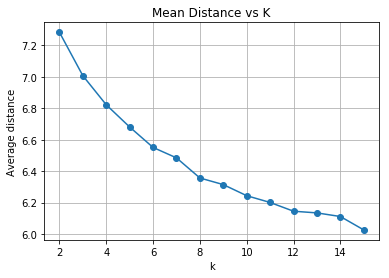

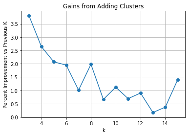

```python
# Investigate the change in within-cluster distance across number of clusters.
# HINT: Use matplotlib's plot function to visualize this relationship.
# Plot for average distance vs k
plt.figure()
plt.plot(result["k"], result["mean_distance"], marker='o')
plt.xlabel("k")
plt.ylabel("Average distance")
plt.title("Mean Distance vs K")
plt.grid(True)
plt.show()

# Plot for percentage improvement if you increase k by 1
plt.figure()
plt.plot(result["k"], result['relationship_drop_percent'], marker='o')
plt.xlabel("k")
plt.ylabel("Percent Improvement vs Previous K")
plt.title("Gains from Adding Clusters")
plt.grid(True)
plt.show()
```

```python
# Re-fit the k-means model with the selected number of clusters and obtain
# cluster predictions for the general population demographics data.
kms = X_pca.astype("float32", copy=False)

# Using 12 for k final to account for elbow
final_k_means = MiniBatchKMeans(n_clusters=12,
                               batch_size=8192,
                               n_init=10,
                               max_iter=100,
                               random_state=0
                              ).fit(kms)

print(f"Final Mean Distance: {np.sqrt(final_k_means.inertia_ / kms.shape[0]).round(4)}")
```

```
Final Mean Distance: 6.1446
```

### Discussion 3.1: Apply Clustering to General Population

I reviewed the k-means using k = 2 through 15 with the 40 component data previously identified. The average was tracked using the Euclidean distance and we can see from the plots/review summaries above that the curve dropped very quickly around k = 6 where it begins to briefly flatten. It continued to fall and improve until approximately k = 11. With the elbow viewable in the plot, k = 12 was used for the final number of clusters.

### Step 3.2: Apply All Steps to the Customer Data

```python
# Load in the customer demographics data.
customers = pd.read_csv("Udacity_CUSTOMERS_Subset.csv", sep = ";")

customers.shape
```

```
(191652, 85)
```

```python
# Apply preprocessing, feature transformation, and clustering from the general
# demographics onto the customer data, obtaining cluster predictions for the
# customer demographics data.

customers_clean = clean_data(customers, feature_summary, missing_map)
customers_working = customers_clean.reindex(columns=azdias_working.columns, fill_value=np.nan)

cust_values = customers_working.values.astype("float32")
cust_impute = imputer.transform(cust_values).astype("float32")
cust_scale = scaler.transform(cust_impute).astype("float32")
XCust = pca.transform(cust_scale).astype("float32")

customers_labels = final_k_means.predict(XCust)

customers_clusters = pd.Series(customers_labels, index=customers_working.index, name="cluster" )
customers_clusters.value_counts().sort_index()
```

```
0      1529
1     28809
2     49276
3      4484
4      1059
5     10976
6      9044
7     48970
8     15254
9      2854
10      952
11    18445
Name: cluster, dtype: int64
```

### Step 3.3: Compare Customer Data to Demographics Data

```python
# Compare the proportion of data in each cluster for the customer data to the
# proportion of data in each cluster for the general population.
population_count = pd.Series(final_k_means.labels_).value_counts().sort_index()
population_percent = population_count / population_count.sum()

customer_count = pd.Series(customers_labels).value_counts().sort_index()
customer_percent = customer_count / customer_count.sum()

comparing = pd.DataFrame({
    "Population": population_count,
    "Customers": customer_count,
    "Population_%": (population_percent * 100).round(2),
    "Customer_%": (customer_percent * 100).round(2),
})

comparing["Lift_Pts"] = (comparing["Customer_%"] - comparing["Population_%"]).round(2)
comparing["Ratio"] = (customer_percent / population_percent).round(2)
comparing
```

|  | Population | Customers | Population_% | Customer_% | Lift_Pts | Ratio |
| --- | --- | --- | --- | --- | --- | --- |
| 0 | 78667 | 1529 | 9.86 | 0.80 | -9.06 | 0.08 |
| 1 | 64600 | 28809 | 8.10 | 15.03 | 6.93 | 1.86 |
| 2 | 101292 | 49276 | 12.70 | 25.71 | 13.01 | 2.03 |
| 3 | 40862 | 4484 | 5.12 | 2.34 | -2.78 | 0.46 |
| 4 | 51622 | 1059 | 6.47 | 0.55 | -5.92 | 0.09 |
| 5 | 84472 | 10976 | 10.59 | 5.73 | -4.86 | 0.54 |
| 6 | 51220 | 9044 | 6.42 | 4.72 | -1.70 | 0.74 |
| 7 | 86897 | 48970 | 10.89 | 25.55 | 14.66 | 2.35 |
| 8 | 98552 | 15254 | 12.35 | 7.96 | -4.39 | 0.64 |
| 9 | 3248 | 2854 | 0.41 | 1.49 | 1.08 | 3.66 |
| 10 | 52055 | 952 | 6.52 | 0.50 | -6.02 | 0.08 |
| 11 | 84350 | 18445 | 10.57 | 9.62 | -0.95 | 0.91 |

```python
# Group information for those missing > 30%
missing_population = len(azdias_high) if "azdias_high" in globals() else 0
missing_customer = int((customers.isna().mean(axis=1) > .3).sum())
pd.DataFrame({"Population": [missing_population], "Customers": [missing_customer]}, index=["Missing > 30%"])
```

|  | Population | Customers |
| --- | --- | --- |
| Missing > 30% | 93384 | 49943 |

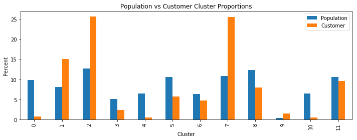

```python
# Visulation bar plot to compare the population vs. customers

ax = (comparing[["Population_%", "Customer_%"]]).plot(kind="bar", figsize=(10,4))
ax.set_title("Population vs Customer Cluster Proportions")
ax.set_xlabel("Cluster")
ax.set_ylabel("Percent")
ax.legend(["Population", "Customer"])
plt.tight_layout()
```

```python
# Function to retrieve high and lows for over & underrepresented profiles
overrep = int(comparing["Lift_Pts"].idxmax())
underrep = int(comparing["Lift_Pts"].idxmin())

pca_center = final_k_means.cluster_centers_
scale_center = pca.inverse_transform(final_k_means.cluster_centers_)
original_center = scaler.inverse_transform(scale_center)

features = azdias_working.columns

def cluster_profile(clust, topn=12):
    z = pd.Series(scale_center[clust], index=features)
    k = pd.Series(original_center[clust], index=features)
    positive_idx = z.nlargest(topn).index
    negative_idx = z.nsmallest(topn).index
    pos = pd.DataFrame({"z": z[positive_idx].round(2), "original": k[positive_idx].round(2)})
    neg = pd.DataFrame({"z": z[negative_idx].round(2), "original": k[negative_idx].round(2)})
    return pos, neg

positive_over, negative_over = cluster_profile(overrep, topn=12)
positive_under, negative_under = cluster_profile(underrep, topn=12)

print(f"Overrepresented Cluster: {overrep}")
print(f"Underrepresented Cluster: {underrep}")
```

```
Overrepresented Cluster: 7
Underrepresented Cluster: 0
```

```python
# What kinds of people are part of a cluster that is overrepresented in the
# customer data compared to the general population?
print(f"Overrepresented cluster drivers (positive): {positive_over}")
print(f"Overrepresented cluster drivers (negative): {negative_over}")
```

```
Overrepresented cluster drivers (positive):                           z  original
SEMIO_RAT              1.41      6.22
SEMIO_TRADV            1.25      5.93
FINANZ_ANLEGER         1.03      4.36
SEMIO_PFLICHT          0.96      5.97
FINANZ_UNAUFFAELLIGER  0.96      4.00
ANREDE_KZ              0.90      0.97
PJ_DECADE              0.90   1986.03
FINANZ_SPARER          0.87      4.00
SEMIO_DOM              0.80      6.02
SEMIO_KAEM             0.69      5.58
SEMIO_REL              0.68      5.29
SEMIO_MAT              0.61      5.05
Overrepresented cluster drivers (negative):                          z  original
ALTERSKATEGORIE_GROB -1.08      1.69
SEMIO_VERT           -0.88      2.57
FINANZ_VORSORGER     -0.85      2.26
SEMIO_SOZ            -0.78      2.62
FINANZ_MINIMALIST    -0.65      2.16
RETOURTYP_BK_S       -0.63      2.53
PLZ8_BAUMAX          -0.56      1.11
PLZ8_ANTG4           -0.54      0.32
SEMIO_LUST           -0.54      3.20
PLZ8_ANTG3           -0.53      1.09
ORTSGR_KLS9          -0.51      4.13
W_KEIT_KIND_HH       -0.49      3.31
```

```python
# What kinds of people are part of a cluster that is underrepresented in the
# customer data compared to the general population?
print(f"Underrepresented cluster drivers (positive): {positive_under}")
print(f"Underrepresented cluster drivers (negative): {negative_under}")
```

```
Underrepresented cluster drivers (positive):                    z  original
SEMIO_RAT       1.32      6.08
SEMIO_PFLICHT   1.07      6.16
FINANZ_SPARER   1.03      4.24
SEMIO_KAEM      1.02      6.19
SEMIO_TRADV     1.01      5.50
ANREDE_KZ       0.96      1.00
PLZ8_ANTG3      0.91      2.49
PLZ8_BAUMAX     0.89      3.20
PLZ8_ANTG4      0.88      1.34
SEMIO_DOM       0.84      6.09
PJ_DECADE       0.82   1984.96
FINANZ_ANLEGER  0.82      4.05
Underrepresented cluster drivers (negative):                          z  original
FINANZ_MINIMALIST    -1.35      1.20
SEMIO_VERT           -1.03      2.27
ALTERSKATEGORIE_GROB -1.03      1.75
FINANZ_VORSORGER     -0.90      2.19
MOBI_REGIO           -0.89      1.72
PLZ8_ANTG1           -0.89      1.39
KBA05_ANTG1          -0.81      0.36
KBA05_GBZ            -0.80      2.11
PLZ8_GBZ             -0.69      2.61
INNENSTADT           -0.67      3.19
KONSUMNAEHE          -0.64      2.04
CAMEO_LIFESTAGE      -0.60      1.99
```

### Discussion 3.3: Compare Customer Data to Demographics Data

The clustering analysis shows that the company’s customer base is uneven across demographics. Some clusters are strongly overrepresented compared to the general population, while others are underrepresented.

This analysis confirms that the best opportunities are not in the broad population but in specific segments. Cluster 7, for example, provides a clear marketing target, while groups such as Cluster 0 represent smaller revenue and potentially wasted resources. The company can maximize revenue potential and build long-term customers by directing resources toward overrepresented segments.